# Processing raw MiSeq Data

Devin R Leopold

March 22, 2020

Sample types are indicated by the prefix of the sample IDs in the raw reads fastq.gz file names:  
* Sp - Experimental species pool samples  
* N - Negative controls  
* M - Mock communities  
* F - Single species samples prepared from pure cultures of isolates used in the experiment

## Prepare environment

Load packages

```r
library(tidyverse)
library(magrittr)
library(dada2)
library(Biostrings)
library(foreach)
library(knitr)
library(phyloseq)
library(ape)
library(phytools)
```

Load fasta of target amplicons for all isolates in experiment

```r
targets <- readDNAStringSet("data/AllIsolates_ITS2_200bp.fasta")
#and the host plant (Vaccinium calycinum)
host <- readDNAStringSet("data/VACCAL_ITS2_200bp.fasta")
```

key to which isolates were included in experimental species pools

```r
pools <- read.csv("data/SpeciesPoolKey.csv", as.is=T, header=T) %>% select(-num,-var,-mean)
```

key linking sample IDs to species pools

```r
sampKey <- read.csv("data/PlantData.csv", as.is=T, header=T)
```

key to mock communities

```r
mock <- read.csv("data/MockCommunities.csv", as.is=T, header=T)
```

keys to isolates used in expt

```r
sites <- read.csv("data/sites.csv", as.is=T)
isoKey <- read.csv("data/cultureData.csv",as.is=T) %>% left_join(sites) %>% mutate(site_logAge=log10(site_age)) %>%
  .[match(names(targets),.$isoID),]
```

Sample names

```r
samps <- list.files("data/MiSeq/", pattern="R1_001.fastq.gz") %>% strsplit(., "_",fixed=T) %>% sapply(., `[`, 1) %>% sort
#Skip single species sample for ISO.57 which was not included in the experiment
samps %<>% .[samps!="F57"]
```

Paths to fwd and rev raw reads

```r
R1.raw <- list.files("data/MiSeq/", pattern="R1_001.fastq.gz",full.names = T) %>% sort
R2.raw <- list.files("data/MiSeq/", pattern="R2_001.fastq.gz",full.names = T) %>% sort
```

## Trim gene primers

make directory for cutadapt output

```r
dir.create("output/MiSeq/cutadapt", recursive = T, showWarnings = F)
```

loop over raw paired read files

```r
for(samp in samps){
  #skip trimming if all files have already been processed
  if(samp==samps[1] & length(list.files("output/MiSeq/cutadapt"))==2*length(samps)){break}
  #path to current raw reads
  FWD <- paste0(samp,"_") %>% grep(R1.raw, value=T)
  REV <- paste0(samp,"_") %>% grep(R2.raw, value=T)

  #output paths
  FWD.out <- file.path("output/MiSeq/cutadapt",paste0(samp,".R1.trim.fastq.gz"))
  REV.out <- file.path("output/MiSeq/cutadapt",paste0(samp,".R2.trim.fastq.gz"))

  #set cutadapt parameters
  cutadapt.flags <- paste("-g GCATCGATGAAGAACGC", #FWD gene primer
                          "-G TCCGCTTATTGATATGC",  #REV gene primer
                          "--overlap 17",
                          "-e 0.2",
                          "-o ", FWD.out,
                          "-p ", REV.out,
                          "--discard-untrimmed",
                          FWD, REV)
  system2("/home/harpua/miniconda3/bin/cutadapt", args = cutadapt.flags)
}
```

## Filter and crop

```r
# Plot example quality profile
```

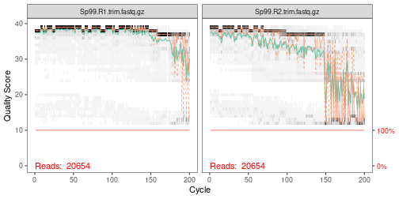

```r
plotQualityProfile(c("output/MiSeq/cutadapt/Sp99.R1.trim.fastq.gz","output/MiSeq/cutadapt/Sp99.R2.trim.fastq.gz"))
```

Identify paths to fwd trimmed reads.

```r
R1.trimmed <- list.files("output/MiSeq/cutadapt", pattern="R1.trim",full.names = T)  %>% sort
```

Create directory and paths for filtering output

```r
dir.create("output/MiSeq/filtered", showWarnings = F)
R1.filtered <- gsub("output/MiSeq/cutadapt","output/MiSeq/filtered", R1.trimmed)  %>% sort
names(R1.filtered) <- samps
```

filter low quality reads and truncate to 200 bp

```r
filterAndTrim(R1.trimmed, R1.filtered,
              maxN=0,
              truncLen=200,
              maxEE=2,
              multithread = T)
```

## Denoise with DADA2

create directory for output

```r
dir.create("output/MiSeq/dada2", showWarnings = F)
```

learn errors

```r
errF <- learnErrors(R1.filtered, multithread = T, randomize = T, nbases = 1e9)
```

```
## 1004391600 total bases in 5021958 reads from 232 samples will be used for learning the error rates.
```

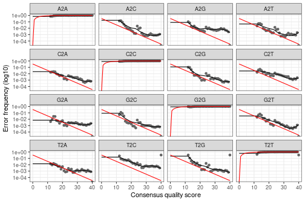

```r
plotErrors(errF, nominalQ=TRUE)
```

denoise samples one at a time setting the expected sequences as priors for each sample

```r
denoised.list <- lapply(samps,function(x) NULL) %>% setNames(samps)
for(samp in samps){

  # Identify expected amplicons (dada priors)
  identifier <- substring(samp,1,1)
  if(identifier=="N"){priors <- host} #Negative controls
  if(identifier=="S"){                #Experimental species pool samples
    pool <- sampKey$poolID[sampKey$sampID==samp]
    expected <- pools %>% filter(poolID==pool) %>% grep("ISO",.,value = T)
    if(pool=="C"){priors <- host} else{priors <- targets[expected] %>% c(host)}
  }
  if(identifier=="M"){                #Mock community sample
    priors <- targets[mock$Spp]%>% c(host)
  }
  if(identifier=="F"){                #Pure culture samples
    expected <- substring(samp,2,4) %>% paste0("ISO.",.)
    priors <- targets[expected] %>% c(host)
  }

  #denoise current samp
  samp.path <- paste0(samp,".R1") %>% grep(R1.filtered, value=T)
  # OMEGA_A reduced from default (1e-40) slightly after preliminary check of single species samples to improve denoising
  denoised <- dada(samp.path, err=errF, multithread=TRUE, priors=priors, verbose=F, OMEGA_A=1e-45, MIN_ABUNDANCE=2)

  #make OTU table
  otu.table <- makeSequenceTable(denoised)

  #remove chimeras
  #otu.table %<>% removeBimeraDenovo(multithread=T)

  #Identify and rename expected sequences
  #Initial trials with only dada2 "exact" sequence variants did not correctly resolve all expected taxa
  #Collapse sequence variants with < 98% similarity (4bp) difference
  for(i in 1:ncol(otu.table)){
    dists <- stringdist::stringdist(colnames(otu.table)[i],as.character(priors))
    if(min(dists)<4){
      colnames(otu.table)[i] <- names(priors)[order(dists)[1]]}
  }
  otu.table %<>% collapseNoMismatch(identicalOnly = T) #collapse otus assigned to the same expected seq
  #add sample ID
  rownames(otu.table) <- samp

  #add to list of denoised OTU tables
  denoised.list[[samp]] <- otu.table
}
```

merge otu tables

```r
full.otu.table <- mergeSequenceTables(tables=denoised.list)
```

Relabel “unexpected” OTUs. This includes OTUs that were not in any of the inoculations or expected OTUs that showed up somewhere they were not expected (ie in a microcosm where they were not inoculated)

```r
otuCounter <- 1
for(i in 1:ncol(full.otu.table)){
  seq <- colnames(full.otu.table)[i]
  if(nchar(seq)<20){next}
  if(seq %in% as.character(targets)){
    ID <- targets[match(seq, as.character(targets))] %>% names %>% .[1] %>% paste0("x",.)
  } else {
    ID <- paste0("xOTU.",otuCounter)
    seq %<>% DNAStringSet
    names(seq) <- ID
    #write unexpected sequences to fasta
    if(otuCounter==1){
      writeXStringSet(seq,"output/MiSeq/dada2/unexpected.fasta")} else{
        writeXStringSet(seq,"output/MiSeq/dada2/unexpected.fasta", append=T)}
    otuCounter %<>% add(1)} #update counter for next unexpected OTU
  colnames(full.otu.table)[i] <- ID
}
```

write the full denoised otu table to file

```r
write.csv(full.otu.table,"output/csv/outTable.denoised.csv")
```

## Single species samples

The library included pure-culture samples of each of the 54 isolates used in the experiment. These samples can be used to verify the prior sangar sequencing of the isolates and will also serve as positive controls. Initial processing of these samples identified 3 isolates (F10, F61, F90) whoes ITS2 amplicon inferred from the denoised MiSeq data varied from earlier Sangar sequencing. The library of priors was updated and the MiSeq data processing was rerun. subset single species samples and summarize the % of reads that map to the expected amplicon

```r
singles <- full.otu.table %>% .[grepl("^F",rownames(.)),] %>% .[,colSums(.)>0]
foreach(i = rownames(singles), .combine = bind_rows) %do% {
  isolate <- paste0("ISO.",substr(i,2,5))
  list(Isolate = isolate,
       NumberOfAmplicons = sum(singles[i,] > 0),
       SeqDepth = sum(singles[i,]),
       PctExpected = round(100*singles[i,isolate]/sum(singles[i,]),2))
} -> singles.summary
```

Almost all reads map to the correct amplicon.

```r
kable(singles.summary, caption = "Summary of single species samples")
```

Summary of single species samples

| Isolate | NumberOfAmplicons | SeqDepth | PctExpected |
| --- | --- | --- | --- |
| ISO.10 | 1 | 3557 | 100.00 |
| ISO.11 | 1 | 3111 | 100.00 |
| ISO.12 | 1 | 3744 | 100.00 |
| ISO.13 | 1 | 3982 | 100.00 |
| ISO.14 | 1 | 3078 | 100.00 |
| ISO.15 | 1 | 3063 | 100.00 |
| ISO.18 | 1 | 1547 | 100.00 |
| ISO.2 | 1 | 2806 | 100.00 |
| ISO.20b | 1 | 4716 | 100.00 |
| ISO.21 | 1 | 5095 | 100.00 |
| ISO.22 | 1 | 887 | 100.00 |
| ISO.23 | 1 | 2891 | 100.00 |
| ISO.25 | 1 | 2630 | 100.00 |
| ISO.26 | 1 | 4354 | 100.00 |
| ISO.27 | 1 | 6000 | 100.00 |
| ISO.28a | 1 | 4704 | 100.00 |
| ISO.29 | 1 | 635 | 100.00 |
| ISO.32 | 1 | 5901 | 100.00 |
| ISO.33 | 1 | 2460 | 100.00 |
| ISO.34 | 1 | 2773 | 100.00 |
| ISO.35 | 1 | 1483 | 100.00 |
| ISO.39 | 1 | 3452 | 100.00 |
| ISO.40 | 1 | 4347 | 100.00 |
| ISO.41a | 1 | 2676 | 100.00 |
| ISO.41b | 1 | 5006 | 100.00 |
| ISO.43 | 1 | 4355 | 100.00 |
| ISO.44 | 1 | 5297 | 100.00 |
| ISO.48 | 2 | 4868 | 99.88 |
| ISO.49 | 2 | 5417 | 99.82 |
| ISO.53 | 1 | 4475 | 100.00 |
| ISO.55 | 1 | 3960 | 100.00 |
| ISO.56 | 1 | 5792 | 100.00 |
| ISO.59 | 1 | 3291 | 100.00 |
| ISO.6 | 1 | 4172 | 100.00 |
| ISO.60 | 1 | 2920 | 100.00 |
| ISO.61 | 1 | 132 | 100.00 |
| ISO.63 | 1 | 1506 | 100.00 |
| ISO.68 | 1 | 3582 | 100.00 |
| ISO.69 | 2 | 5069 | 99.86 |
| ISO.70 | 1 | 1705 | 100.00 |
| ISO.74 | 1 | 5283 | 100.00 |
| ISO.79 | 1 | 4834 | 100.00 |
| ISO.82 | 1 | 4880 | 100.00 |
| ISO.85 | 1 | 4838 | 100.00 |
| ISO.86 | 1 | 5516 | 100.00 |
| ISO.87 | 2 | 5712 | 99.93 |
| ISO.88 | 1 | 4765 | 100.00 |
| ISO.90 | 1 | 5170 | 100.00 |
| ISO.91 | 1 | 4445 | 100.00 |
| ISO.92 | 1 | 4210 | 100.00 |
| ISO.93 | 1 | 509 | 100.00 |
| ISO.96 | 1 | 3377 | 100.00 |
| ISO.97 | 1 | 5340 | 100.00 |
| ISO.98 | 1 | 4282 | 100.00 |

## Negative controls

subset negative control samples

```r
neg <- full.otu.table %>% .[grepl("^N",rownames(.)),] %>% .[,colSums(.)>0]
```

Primarily non-target amplicons present and in very low counts.

```r
colSums(neg)
```

```
##  xISO.35  xISO.10  xOTU.67  xOTU.80  xISO.14  xISO.29 xOTU.109 xOTU.112
##        2       24       68       15       13       11       29       49
## xOTU.153  xISO.32 xOTU.164 xOTU.171 xOTU.179 xOTU.180 xOTU.195 xOTU.196
##       16        5        8       10        9        9        7        3
## xOTU.204
##        6
```

there are also plant microcosm that were not inoculated

```r
controlPlants <- full.otu.table %>% .[rownames(.) %in% sampKey$sampID[sampKey$poolID=="C"],] %>% .[,colSums(.)>0]
```

these controls are dominated by host sequences and non-target otus (in low abundance).

```r
colSums(controlPlants)
```

```
## V.Calycinum     xISO.26     xISO.10     xOTU.26     xISO.88     xOTU.67
##       55743         305          25         160         110          48
##     xOTU.80     xISO.63     xISO.29    xOTU.109    xOTU.126      xISO.2
##          24           5          14          11          34           4
##    xOTU.147    xOTU.157    xOTU.160    xOTU.163    xOTU.166     xISO.97
##          18          14          13          12          11           8
##    xOTU.175    xOTU.178    xOTU.190    xOTU.194    xOTU.197    xOTU.198
##          10          10           8           8           7           7
##    xOTU.200    xOTU.205    xOTU.207    xOTU.211    xOTU.216    xOTU.219
##           7           6           6           5           3           2
```

we can also look at how prevalant non-target otus are in the experimental samples

```r
expt <- full.otu.table %>% .[grepl("^Sp",rownames(.)),] %>%
  .[!(rownames(.) %in% sampKey$sampID[sampKey$poolID=="C"]),] %>% .[,colSums(.)>0]
```

```r
round(100*rowSums(expt[,grepl("xOTU",colnames(expt))])/rowSums(expt),2) %>% sort(decreasing=T) %>% .[.>0]
```

```
##  Sp97  Sp45  Sp60 Sp312 Sp233 Sp263 Sp146 Sp236  Sp50 Sp294 Sp295  Sp18 Sp145
## 27.79 27.26 26.88 23.72 23.02 21.97 20.02 18.95 18.45 17.13 14.67 11.67  9.79
## Sp202  Sp55 Sp307 Sp244 Sp298 Sp250  Sp51  Sp43 Sp301 Sp286 Sp112 Sp115 Sp249
##  9.43  8.57  7.96  7.56  6.06  5.91  5.73  5.17  5.15  5.04  4.85  4.45  4.45
##  Sp49  Sp26 Sp252 Sp203 Sp132 Sp162  Sp32 Sp205 Sp188  Sp27 Sp173 Sp133 Sp221
##  4.17  3.82  3.59  3.34  3.31  3.27  3.21  3.20  3.18  3.09  3.06  2.89  2.82
## Sp310 Sp296 Sp243 Sp309 Sp240 Sp266 Sp211 Sp148 Sp139 Sp314 Sp101 Sp238 Sp239
##  2.82  2.78  2.65  2.64  2.56  2.45  2.38  2.28  2.27  2.24  2.22  2.22  2.21
## Sp251 Sp283  Sp40 Sp227 Sp128  Sp65  Sp92 Sp253  Sp30  Sp21 Sp195 Sp280  Sp86
##  2.16  2.15  2.14  2.13  2.12  2.12  2.12  2.11  2.10  2.09  2.04  2.02  1.99
## Sp315 Sp100  Sp69  Sp76 Sp270  Sp87 Sp259 Sp209 Sp114 Sp268  Sp71 Sp316 Sp165
##  1.94  1.92  1.92  1.92  1.88  1.87  1.86  1.83  1.82  1.77  1.77  1.76  1.75
##  Sp41  Sp64 Sp118  Sp78  Sp77  Sp44 Sp229 Sp131 Sp137 Sp107 Sp297  Sp82 Sp197
##  1.71  1.69  1.68  1.66  1.64  1.61  1.60  1.58  1.54  1.53  1.52  1.52  1.51
## Sp292 Sp163 Sp277 Sp102 Sp306 Sp149 Sp254 Sp113 Sp134 Sp144  Sp38 Sp201 Sp303
##  1.51  1.50  1.49  1.46  1.46  1.44  1.44  1.39  1.39  1.39  1.38  1.35  1.35
##  Sp98 Sp123  Sp37 Sp214  Sp79  Sp35 Sp161 Sp242  Sp95 Sp206  Sp28 Sp311  Sp91
##  1.34  1.33  1.29  1.28  1.28  1.27  1.24  1.23  1.23  1.22  1.22  1.22  1.21
## Sp181 Sp207 Sp300 Sp159  Sp33  Sp36  Sp80 Sp219 Sp245 Sp255  Sp17 Sp222  Sp46
##  1.19  1.12  1.10  1.08  1.07  1.05  1.05  1.02  1.00  0.97  0.96  0.96  0.96
## Sp212  Sp42 Sp196 Sp160 Sp198 Sp164 Sp120 Sp237  Sp48 Sp143  Sp99 Sp228 Sp103
##  0.95  0.95  0.93  0.92  0.89  0.88  0.87  0.87  0.87  0.85  0.79  0.78  0.77
## Sp204 Sp305 Sp124 Sp210 Sp172 Sp193 Sp235  Sp23  Sp34  Sp81 Sp261 Sp152 Sp171
##  0.77  0.77  0.76  0.76  0.74  0.73  0.73  0.72  0.71  0.71  0.70  0.69  0.67
## Sp178 Sp269 Sp293  Sp59  Sp90 Sp104 Sp105 Sp220 Sp246  Sp25 Sp169 Sp232 Sp127
##  0.67  0.62  0.61  0.61  0.61  0.59  0.59  0.59  0.59  0.59  0.58  0.57  0.56
## Sp290 Sp158 Sp247  Sp56  Sp57  Sp19 Sp285 Sp257 Sp265 Sp174 Sp109 Sp166 Sp313
##  0.56  0.55  0.55  0.55  0.55  0.54  0.54  0.52  0.52  0.51  0.50  0.50  0.50
##  Sp63  Sp84 Sp150 Sp271 Sp302 Sp216 Sp176 Sp282  Sp75  Sp93  Sp20 Sp200  Sp22
##  0.50  0.49  0.48  0.48  0.47  0.46  0.45  0.45  0.45  0.45  0.43  0.43  0.43
## Sp299 Sp116 Sp167 Sp264 Sp130 Sp241 Sp274 Sp278  Sp39  Sp58 Sp110 Sp153 Sp213
##  0.43  0.42  0.41  0.41  0.40  0.40  0.40  0.40  0.40  0.40  0.38  0.38  0.38
## Sp157 Sp156  Sp47 Sp136 Sp140  Sp85 Sp108 Sp281 Sp111 Sp180 Sp248 Sp258 Sp275
##  0.37  0.36  0.35  0.34  0.33  0.31  0.30  0.30  0.28  0.27  0.27  0.27  0.27
##  Sp61 Sp183 Sp231 Sp273  Sp62 Sp154 Sp125 Sp155 Sp187 Sp208 Sp225 Sp122 Sp267
##  0.27  0.26  0.26  0.26  0.26  0.25  0.22  0.22  0.22  0.22  0.22  0.21  0.21
## Sp168  Sp31 Sp117  Sp68 Sp119 Sp147 Sp141 Sp175 Sp279 Sp194 Sp224 Sp304 Sp142
##  0.20  0.20  0.19  0.19  0.18  0.18  0.17  0.17  0.17  0.16  0.16  0.16  0.14
## Sp170 Sp272 Sp284 Sp288  Sp74 Sp135 Sp287 Sp217  Sp24  Sp53  Sp66 Sp276 Sp289
##  0.12  0.12  0.12  0.12  0.12  0.11  0.11  0.10  0.10  0.10  0.10  0.09  0.09
## Sp138 Sp226  Sp94  Sp83 Sp230  Sp29  Sp72  Sp73 Sp308  Sp88 Sp106 Sp256  Sp52
##  0.08  0.08  0.08  0.07  0.06  0.06  0.06  0.05  0.04  0.04  0.03  0.03  0.03
## Sp215 Sp260
##  0.02  0.02
```

```r
colSums(expt[,grepl("xOTU",colnames(expt))] > 0) %>% sort(decreasing=T)
```

```
##   xOTU.2   xOTU.1   xOTU.3   xOTU.7  xOTU.11  xOTU.26   xOTU.8  xOTU.19
##      107       98       68       55       33       32       31       28
##  xOTU.27   xOTU.4   xOTU.6   xOTU.9  xOTU.24  xOTU.29  xOTU.18  xOTU.58
##       25       23       22       22       21       21       20       20
##  xOTU.16  xOTU.13  xOTU.20  xOTU.12  xOTU.49  xOTU.32  xOTU.41  xOTU.53
##       19       18       17       13       13       12       12       12
##  xOTU.39   xOTU.5  xOTU.60  xOTU.25  xOTU.45  xOTU.48  xOTU.10  xOTU.51
##       11       10       10        9        9        9        8        8
##  xOTU.21  xOTU.36  xOTU.38  xOTU.42  xOTU.65  xOTU.15  xOTU.35  xOTU.47
##        7        7        7        7        7        6        6        6
##  xOTU.56  xOTU.64  xOTU.31  xOTU.37  xOTU.44  xOTU.46  xOTU.55  xOTU.62
##        6        6        5        5        5        5        5        5
##  xOTU.67  xOTU.73  xOTU.80 xOTU.118  xOTU.17  xOTU.43  xOTU.50  xOTU.52
##        5        5        5        5        4        4        4        4
##  xOTU.72  xOTU.75  xOTU.78  xOTU.82  xOTU.91  xOTU.23  xOTU.63  xOTU.71
##        4        4        4        4        4        3        3        3
##  xOTU.74  xOTU.76  xOTU.81  xOTU.83  xOTU.85  xOTU.88  xOTU.89  xOTU.94
##        3        3        3        3        3        3        3        3
##  xOTU.96 xOTU.102 xOTU.109 xOTU.120  xOTU.40  xOTU.54  xOTU.68  xOTU.70
##        3        3        3        3        2        2        2        2
##  xOTU.84  xOTU.87  xOTU.90  xOTU.92  xOTU.99 xOTU.100 xOTU.101 xOTU.105
##        2        2        2        2        2        2        2        2
## xOTU.107 xOTU.114 xOTU.116 xOTU.119 xOTU.122 xOTU.124 xOTU.136 xOTU.137
##        2        2        2        2        2        2        2        2
## xOTU.141 xOTU.142 xOTU.143  xOTU.14  xOTU.22  xOTU.28  xOTU.30  xOTU.33
##        2        2        2        1        1        1        1        1
##  xOTU.34  xOTU.57  xOTU.59  xOTU.61  xOTU.66  xOTU.69  xOTU.77  xOTU.79
##        1        1        1        1        1        1        1        1
##  xOTU.86  xOTU.93  xOTU.95  xOTU.97  xOTU.98 xOTU.103 xOTU.104 xOTU.106
##        1        1        1        1        1        1        1        1
## xOTU.108 xOTU.110 xOTU.111 xOTU.113 xOTU.115 xOTU.117 xOTU.123 xOTU.125
##        1        1        1        1        1        1        1        1
## xOTU.127 xOTU.128 xOTU.129 xOTU.130 xOTU.131 xOTU.132 xOTU.133 xOTU.134
##        1        1        1        1        1        1        1        1
## xOTU.135 xOTU.139 xOTU.140 xOTU.144 xOTU.145 xOTU.146 xOTU.148 xOTU.149
##        1        1        1        1        1        1        1        1
## xOTU.150 xOTU.151 xOTU.152 xOTU.154 xOTU.155 xOTU.156 xOTU.158 xOTU.159
##        1        1        1        1        1        1        1        1
## xOTU.161 xOTU.162 xOTU.164 xOTU.165 xOTU.167 xOTU.168 xOTU.169 xOTU.172
##        1        1        1        1        1        1        1        1
## xOTU.173 xOTU.174 xOTU.176 xOTU.177 xOTU.181 xOTU.182 xOTU.183 xOTU.184
##        1        1        1        1        1        1        1        1
## xOTU.185 xOTU.186 xOTU.187 xOTU.188 xOTU.189 xOTU.191 xOTU.192 xOTU.193
##        1        1        1        1        1        1        1        1
## xOTU.196 xOTU.199 xOTU.201 xOTU.202 xOTU.203 xOTU.206 xOTU.208 xOTU.209
##        1        1        1        1        1        1        1        1
## xOTU.210 xOTU.212 xOTU.213 xOTU.214 xOTU.215 xOTU.217 xOTU.218 xOTU.220
##        1        1        1        1        1        1        1        1
## xOTU.221 xOTU.222 xOTU.223 xOTU.224
##        1        1        1        1
```

```r
full.otu.table %<>% .[,grep("^ISO",colnames(.))]
```

## Mock comunity samples

The library included mock community samples where genomic DNA from pure culture isolates was mixed in known proportions. For isolates with similar amplicons (which were not included in the same species pools) only one representative was used in the mock communities, resulting in 35 taxa. subset mock community samples and gather to long format

```r
mock.obs <- full.otu.table %>% .[grepl("^M",rownames(.)),] %>% .[,colSums(.)>0] %>%
  apply(1,FUN=function(x){x/sum(x)}) %>% data.frame %>%
  rownames_to_column("Spp") %>%
  pivot_longer(-Spp,names_to = "pool", values_to = "observed")
```

make corresponding table of known concentrations

```r
mock.known <- mock %>% pivot_longer(-Spp,names_to = "pool", values_to = "known")
```

observed vs. expected looks fairly good, with some evidence for possible species specific biases

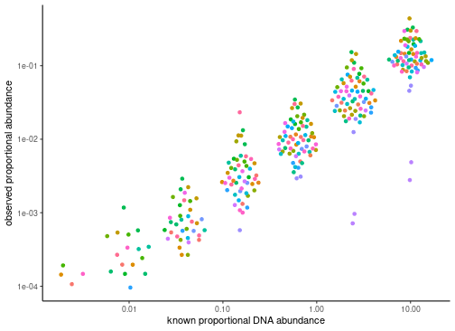

```r
full_join(mock.obs,mock.known) %>%
  ggplot(aes(x=known,y=observed,color=Spp))+
  ggbeeswarm::geom_quasirandom()+
  scale_y_log10(name="observed proportional abundance")+
  scale_x_log10(name="known proportional DNA abundance")+
  theme_classic()+
  theme(legend.position = "none")
```

plot for individual species - clearly some taxa are not as easily detected, but overall there is very good evidence that read abundance tracks known abundance for any given taxa used in the experiment.

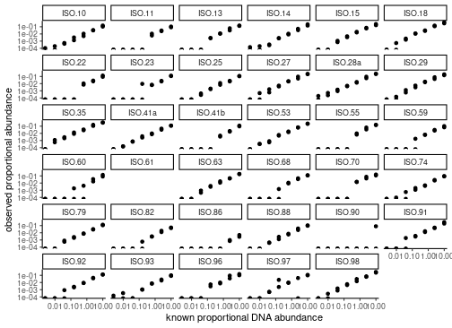

```r
full_join(mock.obs,mock.known) %>%
  ggplot(aes(x=known,y=observed))+
  geom_point()+
  scale_y_log10(name="observed proportional abundance")+
  scale_x_log10(name="known proportional DNA abundance")+
  facet_wrap(~Spp)+
  theme_classic()+
  theme(legend.position = "none")
```

## Experimental samples

Convert to phyloseq object

```r
otu_tab <- full.otu.table %>% .[grepl("^Sp",rownames(.)),] %>% otu_table(taxa_are_rows = F)
```

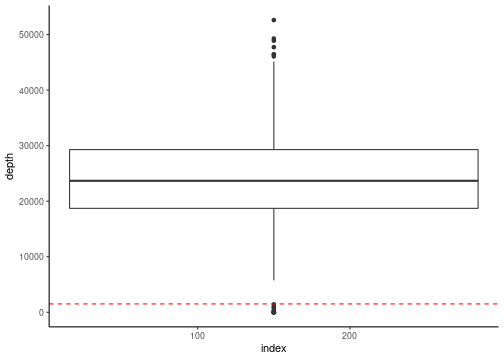

```r
data.frame(depth=sort(rowSums(otu_tab))) %>%
  mutate(index=1:nrow(.)) %>%
  ggplot(aes(y=depth,x=index))+
  geom_boxplot()+
  geom_hline(yintercept=1500,color="red",linetype = "dashed")+
  theme_classic()
```

```r
otu_tab %<>% .[rowSums(otu_tab)>2000,]
```

### Add metadata

convert species pool key into presence absence matrix

```r
pools.mx <- matrix(nrow=nrow(pools),ncol=length(targets), dimnames = list(1:nrow(pools), names(targets)))
for(i in 1:nrow(pools)){
  foo <- pools[i,] %>% c
  pools.mx[i,] <- names(targets) %in% foo
}
```

write pool composition matrix to file

```r
write.csv(pools.mx,"output/csv/pools.mx.csv")
```

Read in phylogenetic tree for calculating Faith’s PD

```r
tree <- read.newick("data/LSU_phylo/result.tcs_weighted_phyml/result.tcs_weighted_phyml_tree.txt") %>%
  root("KY109285.1") %>% drop.tip("KY109285.1")
```

summarize pool characteristics

```r
pools.dat <- data.frame(poolID=as.character(pools$poolID),
                        pool_rich=apply(pools.mx,1,function(x){ length(isoKey$site_logAge[x]) }),
                        pool_pd=picante::pd(pools.mx,tree,F)[,1],
                        age_mean=apply(pools.mx,1,function(x){ mean(isoKey$site_logAge[x], na.rm=T) }),
                        age_var=apply(pools.mx,1,function(x){ var(isoKey$site_logAge[x], na.rm=T) }),
                        numThur=apply(pools.mx,1,function(x){ sum(isoKey$site_name[x]=="Thurston", na.rm=T) }),
                        numOla=apply(pools.mx,1,function(x){ sum(isoKey$site_name[x]=="Ola'a", na.rm=T) }),
                        numLaup=apply(pools.mx,1,function(x){ sum(isoKey$site_name[x]=="Laupahoehoe", na.rm=T) }),
                        numKoh=apply(pools.mx,1,function(x){ sum(isoKey$site_name[x]=="Kohala", na.rm=T) }),
                        numKok=apply(pools.mx,1,function(x){ sum(isoKey$site_name[x]=="Kokee", na.rm=T) }),
                        stringsAsFactors =F)
```

Add pool data to sample key

```r
sampKey %<>% left_join(pools.dat) %>% column_to_rownames("sampID")
```

Write pool data to file

```r
write.csv(pools.dat,"output/csv/pools.dat.csv",row.names = F)
```

add mothe plant ID (all half/full sibs)

```r
sampKey$plantMother <- "A10"
sampKey$plantMother[(sampKey$plantID > 80 & sampKey$plantID <= 160) | sampKey$plantID == 321] <- "A11"
sampKey$plantMother[(sampKey$plantID > 160 & sampKey$plantID <= 240) | sampKey$plantID == 322] <- "A6"
sampKey$plantMother[(sampKey$plantID > 240 & sampKey$plantID <= 320) | sampKey$plantID == 324] <- "A30"
sampKey$plantMother %<>% factor
```

Combine otu table and sample data into phyloseq object

```r
phy <- phyloseq(
  otu_tab,
  sample_data(sampKey)
)
```

Save phyloseq object

```r
saveRDS(phy,"output/rds/phy.rds")
```

## Session info

cutadapt

```r
system2("/home/harpua/miniconda3/bin/cutadapt", args = "--version", stdout = T)
```

```
## [1] "2.7"
```

R